# AVOCADO CLASSIFICATION (CONVENTIONAL OR ORGANIC)

# About the Dataset

This data was downloaded from the Hass Avocado Board website in May of 2018 & compiled into a single CSV. Here's how the Hass Avocado Board describes the data on their website: The table below represents weekly 2018 retail scan data for National retail volume (units) and price. Retail scan data comes directly from retailers’ cash registers based on actual retail sales of Hass avocados. Starting in 2013, the table below reflects an expanded, multi-outlet retail data set. Multi-outlet reporting includes an aggregation of the following channels: grocery, mass, club, drug, dollar and military. The Average Price (of avocados) in the table reflects a per unit (per avocado) cost, even when multiple units (avocados) are sold in bags. The Product Lookup codes (PLU’s) in the table are only for Hass avocados. Other varieties of avocados (e.g. greenskins) are not included in this table.

Some relevant columns in the dataset:

- Date - The date of the observation
- AveragePrice - the average price of a single avocado
- type - conventional or organic
- year - the year
- Region - the city or region of the observation
- Total Volume - Total number of avocados sold
- 4046 - Total number of avocados with PLU 4046 sold
- 4225 - Total number of avocados with PLU 4225 sold
- 4770 - Total number of avocados with PLU 4770 sold

# Importing Libraries

Libraries Used are as follows:

- Pandas
- Numpy
- Matplotplib
- Seaborn
- Scikit Learn

```python
import pandas as pd
import numpy as np
import matplotlib.pyplot as plt
import seaborn as sns
%matplotlib inline
```

# Reading CSV file

For reading the CSV file, i used the fucntion read_csv() from Pandas Library.

```python
avc = pd.read_csv('avocado.csv',index_col=0)
```

```python
avc.head()
```

|  | Date | AveragePrice | Total Volume | 4046 | 4225 | 4770 | Total Bags | Small Bags | Large Bags | XLarge Bags | type | year | region |
| --- | --- | --- | --- | --- | --- | --- | --- | --- | --- | --- | --- | --- | --- |
| 0 | 2015-12-27 | 1.33 | 64236.62 | 1036.74 | 54454.85 | 48.16 | 8696.87 | 8603.62 | 93.25 | 0.0 | conventional | 2015 | Albany |
| 1 | 2015-12-20 | 1.35 | 54876.98 | 674.28 | 44638.81 | 58.33 | 9505.56 | 9408.07 | 97.49 | 0.0 | conventional | 2015 | Albany |
| 2 | 2015-12-13 | 0.93 | 118220.22 | 794.70 | 109149.67 | 130.50 | 8145.35 | 8042.21 | 103.14 | 0.0 | conventional | 2015 | Albany |
| 3 | 2015-12-06 | 1.08 | 78992.15 | 1132.00 | 71976.41 | 72.58 | 5811.16 | 5677.40 | 133.76 | 0.0 | conventional | 2015 | Albany |
| 4 | 2015-11-29 | 1.28 | 51039.60 | 941.48 | 43838.39 | 75.78 | 6183.95 | 5986.26 | 197.69 | 0.0 | conventional | 2015 | Albany |

The following is the detailed information about the datasets attributes. It gives the info of the number of rows,null value and the data type of the the respective column.

```python
avc.info()
```

```
<class 'pandas.core.frame.DataFrame'>
Int64Index: 18249 entries, 0 to 11
Data columns (total 13 columns):
Date            18249 non-null object
AveragePrice    18249 non-null float64
Total Volume    18249 non-null float64
4046            18249 non-null float64
4225            18249 non-null float64
4770            18249 non-null float64
Total Bags      18249 non-null float64
Small Bags      18249 non-null float64
Large Bags      18249 non-null float64
XLarge Bags     18249 non-null float64
type            18249 non-null object
year            18249 non-null int64
region          18249 non-null object
dtypes: float64(9), int64(1), object(3)
memory usage: 1.9+ MB
```

Description of the Dataset i.e Different statistical values of each attribute.

```python
avc.describe()
```

|  | AveragePrice | Total Volume | 4046 | 4225 | 4770 | Total Bags | Small Bags | Large Bags | XLarge Bags | year |
| --- | --- | --- | --- | --- | --- | --- | --- | --- | --- | --- |
| count | 18249.000000 | 1.824900e+04 | 1.824900e+04 | 1.824900e+04 | 1.824900e+04 | 1.824900e+04 | 1.824900e+04 | 1.824900e+04 | 18249.000000 | 18249.000000 |
| mean | 1.405978 | 8.506440e+05 | 2.930084e+05 | 2.951546e+05 | 2.283974e+04 | 2.396392e+05 | 1.821947e+05 | 5.433809e+04 | 3106.426507 | 2016.147899 |
| std | 0.402677 | 3.453545e+06 | 1.264989e+06 | 1.204120e+06 | 1.074641e+05 | 9.862424e+05 | 7.461785e+05 | 2.439660e+05 | 17692.894652 | 0.939938 |
| min | 0.440000 | 8.456000e+01 | 0.000000e+00 | 0.000000e+00 | 0.000000e+00 | 0.000000e+00 | 0.000000e+00 | 0.000000e+00 | 0.000000 | 2015.000000 |
| 25% | 1.100000 | 1.083858e+04 | 8.540700e+02 | 3.008780e+03 | 0.000000e+00 | 5.088640e+03 | 2.849420e+03 | 1.274700e+02 | 0.000000 | 2015.000000 |
| 50% | 1.370000 | 1.073768e+05 | 8.645300e+03 | 2.906102e+04 | 1.849900e+02 | 3.974383e+04 | 2.636282e+04 | 2.647710e+03 | 0.000000 | 2016.000000 |
| 75% | 1.660000 | 4.329623e+05 | 1.110202e+05 | 1.502069e+05 | 6.243420e+03 | 1.107834e+05 | 8.333767e+04 | 2.202925e+04 | 132.500000 | 2017.000000 |
| max | 3.250000 | 6.250565e+07 | 2.274362e+07 | 2.047057e+07 | 2.546439e+06 | 1.937313e+07 | 1.338459e+07 | 5.719097e+06 | 551693.650000 | 2018.000000 |

```python
avc.columns
```

```
Index(['Date', 'AveragePrice', 'Total Volume', '4046', '4225', '4770',
       'Total Bags', 'Small Bags', 'Large Bags', 'XLarge Bags', 'type', 'year',
       'region'],
      dtype='object')
```

```python
avc.shape
```

```
(18249, 13)
```

# Visualisation

Data Visualisation is one the important part of Data Science. It gives us a good understanding about the data. It also helps us to derive relations between two attributes of a data set through different kinds of plots. Here, I have used two major libraries in python for visualisation which are Matplotlib and Seaborn. The following plots used in this report are as follows:

- Pairplot: Pair plot is used to understand the best set of features to explain a relationship between two variables.
- Distplot: Flexibly plot a univariate distribution of observations.This function combines the matplotlib hist function (with automatic calculation of a good default bin size) with the seaborn kdeplot() and rugplot() functions.
- Heatmap: It is a representation of data in the form of a map or diagram in which data values are represented as colours.
- Boxplot: It is a simple way of representing statistical data on a plot in which a rectangle is drawn to represent the second and third quartiles, usually with a vertical line inside to indicate the median value. The lower and upper quartiles are shown as horizontal lines either side of the rectangle.
- Barplot: A bar chart or bar graph is a chart or graph that presents categorical data with rectangular bars with heights or lengths proportional to the values that they represent. The bars can be plotted vertically or horizontally.

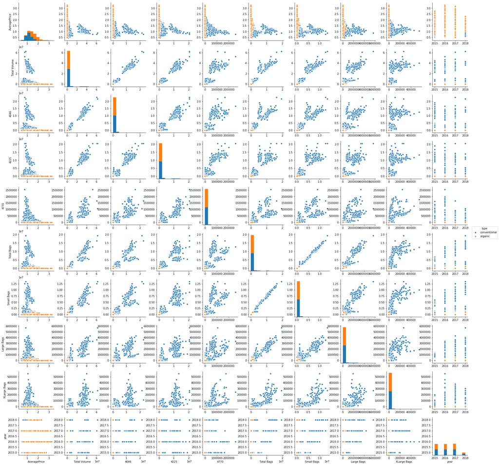

```python
plt.figure(figsize=(12,7))
sns.pairplot(avc,hue='type')
```

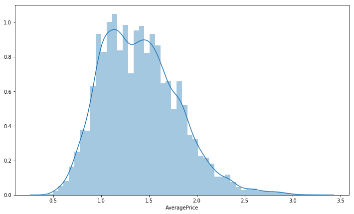

```python
plt.figure(figsize=(12,7))
sns.distplot(avc['AveragePrice'])
```

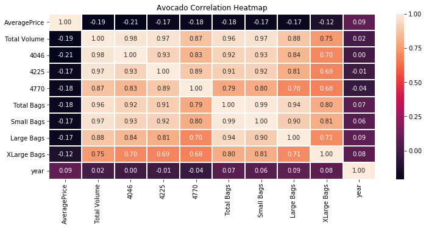

```python
plt.figure(figsize=(12,5))
plt.title('Avocado Correlation Heatmap')
sns.heatmap(avc.corr(),annot=True,linewidths=1,fmt='.2f')
```

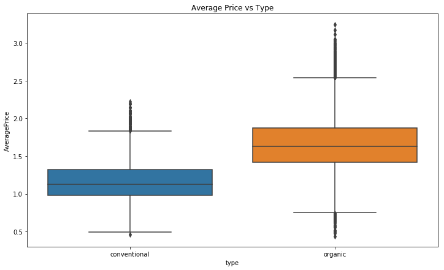

```python
plt.figure(figsize=(12,7))
plt.title('Average Price vs Type')
sns.boxplot(x='type',y='AveragePrice',data=avc)
```

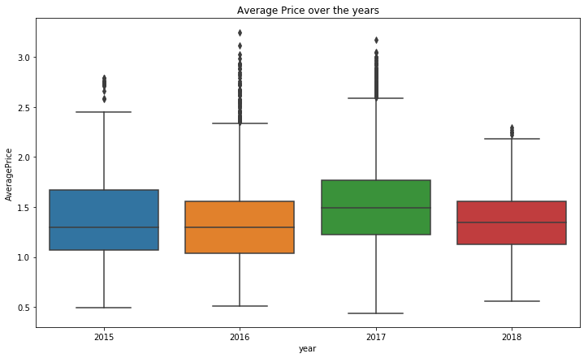

```python
plt.figure(figsize=(12,7))
plt.title('Average Price over the years')
sns.boxplot(x='year',y='AveragePrice',data=avc)
```

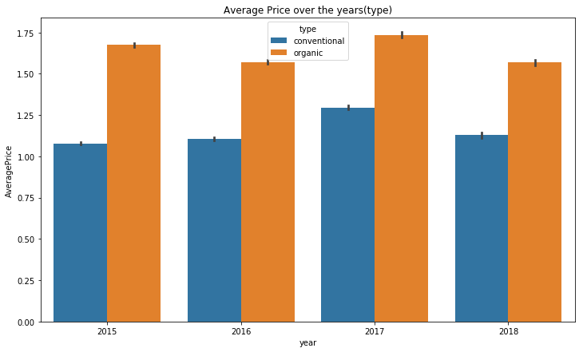

```python
plt.figure(figsize=(12,7))
plt.title('Average Price over the years(type)')
sns.barplot(x='year',y='AveragePrice',data=avc,hue='type')

plt.savefig('barplot.jpg')
```

# Data Preprocessing

Data preprocessing is a data mining technique that involves transforming raw data into an understandable format. Real-world data is often incomplete, inconsistent, and/or lacking in certain behaviors or trends, and is likely to contain many errors. Data preprocessing is a proven method of resolving such issues.

- What is the difference between the independent variables and the dependent variable?

The independent variables are the input data that you have, with each you want to predict something. That something is the dependent variable.

- In Python, why do we create X and y separately?

Because we want to work with Numpy arrays, instead of Pandas dataframes. Numpy arrays are the most convenient format to work with when doing data preprocessing and building Machine Learning models. So we create two separate arrays, one that contains our independent variables (also called the input features), and another one that contains our dependent variable (what we want to predict).

```python
X = avc.drop(['type','region','Date'], axis = 1)
y = avc.type
```

# Categorical Data

- In Python, what do the two ’fit_transform’ methods do?

When the ’fit_transform()’ method is called from the LabelEncoder() class, it transforms the categories strings into integers. For example, it transforms France, Spain and Germany into 0, 1 and 2. Then, when the ’fit_transform()’ method is called from the OneHotEncoder() class, it creates separate columns for each different labels with binary values 0 and 1. Those separate columns are the dummy variables.

```python
from sklearn.preprocessing import LabelEncoder,OneHotEncoder
labelencoder_X = LabelEncoder()
y = labelencoder_X.fit_transform(y)
```

# Splitting the dataset into the Training set and Test set

- What is the difference between the training set and the test set?

The training set is a subset of your data on which your model will learn how to predict the dependent variable with the independent variables. The test set is the complimentary subset from the training set, on which you will evaluate your model to see if it manages to predict correctly the dependent variable with the independent variables.

- Why do we split on the dependent variable?

Because we want to have well distributed values of the dependent variable in the training and test set. For example if we only had the same value of the dependent variable in the training set,our model wouldn’t be able to learn any correlation between the independent and dependent variables.

```python
from sklearn.model_selection import train_test_split
```

```python
X_train, X_test, y_train, y_test = train_test_split(X, y, test_size=0.1,random_state=10)
```

# Feature Scaling

- Do we really have to apply Feature Scaling on the dummy variables?

Yes, if you want to optimize the accuracy of your model predictions. No, if you want to keep the most interpretation as possible in your model.

- When should we use Standardization and Normalization?

Generally you should normalize (normalization) when the data is normally distributed, and scale (standardization) when the data is not normally distributed. In doubt, you should go for standardization. However what is commonly done is that the two scaling methods are tested.

```python
from sklearn.preprocessing import StandardScaler
sc_X = StandardScaler()
X_train = sc_X.fit_transform(X_train)
X_test = sc_X.transform(X_test)
```

# Classification

Classification is a technique where we categorize data into a given number of classes. The main goal of a classification problem is to identify the category/class to which a new data will fall under.

The classifiers used in the project are as follows:

K Nearest Neighbors Classifier :An object is classified by a majority vote of its neighbors, with the object being assigned to the class most common among its k nearest neighbors (k is a positive integer, typically small). If k = 1, then the object is simply assigned to the class of that single nearest neighbor.

[figure not shown]

K-NN in Python

- What is the meaning of n = 5 when building the K-NN model?

n = 5 means that you will train the K-NN model with 5 neighbours.

- What number of neighbors should we choose?

The more you have neighbors, the more this team of neighbors has chance to find correct predictions, and therefore the more your model accuracy has chance to increase. If you have too many neighbors, that will cause overfitting on the training set and the predictions will be poor on new observations in the test set.

Logistic Regression Classifier: Logistic regression is named for the function used at the core of the method, the logistic function.

The logistic function, also called the sigmoid function was developed by statisticians to describe properties of population growth in ecology, rising quickly and maxing out at the carrying capacity of the environment. It’s an S-shaped curve that can take any real-valued number and map it into a value between 0 and 1, but never exactly at those limits.

1 / (1 + e^-value)

Where e is the base of the natural logarithms (Euler’s number or the EXP() function in your spreadsheet) and value is the actual numerical value that you want to transform. Below is a plot of the numbers between -5 and 5 transformed into the range 0 and 1 using the logistic function.

[figure not shown]

Support Vector Machine Classifier : A Support Vector Machine (SVM) is a discriminative classifier formally defined by a separating hyperplane. In other words, given labeled training data (supervised learning), the algorithm outputs an optimal hyperplane which categorizes new examples. In two dimentional space this hyperplane is a line dividing a plane in two parts where in each class lay in either side.

[figure not shown]

```python
from sklearn.neighbors import KNeighborsClassifier
from sklearn.linear_model import LogisticRegression
from sklearn.svm import SVC
```

```python
knn = KNeighborsClassifier(n_neighbors=7)
lr= LogisticRegression()
svc=SVC()
```

```python
knn.fit(X_train,y_train)
lr.fit(X_train,y_train)
svc.fit(X_train,y_train)
```

```
SVC(C=1.0, cache_size=200, class_weight=None, coef0=0.0,
  decision_function_shape='ovr', degree=3, gamma='auto', kernel='rbf',
  max_iter=-1, probability=False, random_state=None, shrinking=True,
  tol=0.001, verbose=False)
```

```python
predictions_1=knn.predict(X_test)
predictions_2=lr.predict(X_test)
predictions_3=svc.predict(X_test)
```

# Evaluation

For Evaluation of the classifiers used in the project, I used metrics library and its following functions:

- Accuracy Score
- Classification Report
- Confusion Matrix

```python
from sklearn.metrics import accuracy_score,classification_report,confusion_matrix
from sklearn import metrics
```

```python
print('K Nearest Neigbours Error values')
print('MAE:', metrics.mean_absolute_error(y_test, predictions_1))
print('MSE:', metrics.mean_squared_error(y_test, predictions_1))
print('RMSE:', np.sqrt(metrics.mean_squared_error(y_test,predictions_1)))
print('Logistic Regression Classifier Error values')
print('MAE:', metrics.mean_absolute_error(y_test, predictions_2))
print('MSE:', metrics.mean_squared_error(y_test, predictions_2))
print('RMSE:', np.sqrt(metrics.mean_squared_error(y_test,predictions_2)))
print('Support Vector Classifier Error values')
print('MAE:', metrics.mean_absolute_error(y_test, predictions_3))
print('MSE:', metrics.mean_squared_error(y_test, predictions_3))
print('RMSE:', np.sqrt(metrics.mean_squared_error(y_test,predictions_3)))
```

```
K Nearest Neigbours Error values
MAE: 0.0306849315068
MSE: 0.0306849315068
RMSE: 0.175171149185
Logistic Regression Classifier Error values
MAE: 0.0668493150685
MSE: 0.0668493150685
RMSE: 0.258552344929
Support Vector Classifier Error values
MAE: 0.0602739726027
MSE: 0.0602739726027
RMSE: 0.245507581559
```

```python
print('K Nearest Neigbours Accuracy Score')
print(accuracy_score(y_test,predictions_1))
print('Logistic Regression Accuracy Score')
print(accuracy_score(y_test,predictions_2))
print('SVM Accuracy Score')
print(accuracy_score(y_test,predictions_3))
```

```
K Nearest Neigbours Accuracy Score
0.969315068493
Logistic Regression Accuracy Score
0.933150684932
SVM Accuracy Score
0.939726027397
```

```python
print('K Nearest Neigbours Classification Report')
print(classification_report(y_test,predictions_1))
print('Logistic Regression Classification Report')
print(classification_report(y_test,predictions_2))
print('SVM Classification Report ')
print(classification_report(y_test,predictions_2))
```

```
K Nearest Neigbours Classification Report
             precision    recall  f1-score   support

          0       0.97      0.97      0.97       904
          1       0.97      0.97      0.97       921

avg / total       0.97      0.97      0.97      1825

Logistic Regression Classification Report
             precision    recall  f1-score   support

          0       0.96      0.91      0.93       904
          1       0.91      0.96      0.94       921

avg / total       0.93      0.93      0.93      1825

SVM Classification Report
             precision    recall  f1-score   support

          0       0.96      0.91      0.93       904
          1       0.91      0.96      0.94       921

avg / total       0.93      0.93      0.93      1825
```

# Grid Search

```python
from sklearn.model_selection import GridSearchCV
```

```python
param_grid1 = {'C': [0.1,1, 10, 100, 1000], 'gamma': [1,0.1,0.01,0.001,0.0001], 'kernel': ['rbf']}
param_grid2 = {'n_neighbors': [3,5,7,9,11,13,15,17,21,23]}
param_grid3 = {'C': [0.1,1, 10, 100, 1000]}
```

One of the great things about GridSearchCV is that it is a meta-estimator. It takes an estimator like SVC, and creates a new estimator, that behaves exactly the same - in this case, like a classifier. You should add refit=True and choose verbose to whatever number you want, higher the number, the more verbose (verbose just means the text output describing the process).

```python
grid1 = GridSearchCV(SVC(),param_grid1,refit=True,verbose=3)
grid2 = GridSearchCV(KNeighborsClassifier(),param_grid2,refit=True,verbose=3)
grid3 = GridSearchCV(LogisticRegression(),param_grid3,refit=True,verbose=3)
```

What fit does is a bit more involved then usual. First, it runs the same loop with cross-validation, to find the best parameter combination. Once it has the best combination, it runs fit again on all data passed to fit (without cross-validation), to built a single new model using the best parameter setting.

```python
grid1.fit(X_train,y_train)
grid2.fit(X_train,y_train)
grid3.fit(X_train,y_train)
```

```
Fitting 3 folds for each of 25 candidates, totalling 75 fits
[CV] C=0.1, gamma=1, kernel=rbf ......................................
[CV]  C=0.1, gamma=1, kernel=rbf, score=0.9137899543378996, total=   1.9s
[CV] C=0.1, gamma=1, kernel=rbf ......................................
```

```
[Parallel(n_jobs=1)]: Done   1 out of   1 | elapsed:    2.9s remaining:    0.0s
```

```
[CV]  C=0.1, gamma=1, kernel=rbf, score=0.9137899543378996, total=   1.9s
[CV] C=0.1, gamma=1, kernel=rbf ......................................
```

```
[Parallel(n_jobs=1)]: Done   2 out of   2 | elapsed:    5.9s remaining:    0.0s
```

[output not shown]

[output cut: 90 more lines]

```
[CV]  C=1000, gamma=0.01, kernel=rbf, score=0.9510502283105022, total=   1.0s
[CV] C=1000, gamma=0.01, kernel=rbf ..................................
[CV]  C=1000, gamma=0.01, kernel=rbf, score=0.9554256485202777, total=   1.2s
[CV] C=1000, gamma=0.001, kernel=rbf .................................
[CV]  C=1000, gamma=0.001, kernel=rbf, score=0.9475799086757991, total=   1.5s
[CV] C=1000, gamma=0.001, kernel=rbf .................................
[CV]  C=1000, gamma=0.001, kernel=rbf, score=0.932054794520548, total=   1.4s
[CV] C=1000, gamma=0.001, kernel=rbf .................................
[CV]  C=1000, gamma=0.001, kernel=rbf, score=0.937157471684326, total=   1.5s
[CV] C=1000, gamma=0.0001, kernel=rbf ................................
[CV]  C=1000, gamma=0.0001, kernel=rbf, score=0.9205479452054794, total=   1.9s
[CV] C=1000, gamma=0.0001, kernel=rbf ................................
[CV]  C=1000, gamma=0.0001, kernel=rbf, score=0.9148858447488585, total=   1.8s
[CV] C=1000, gamma=0.0001, kernel=rbf ................................
[CV]  C=1000, gamma=0.0001, kernel=rbf, score=0.9201680672268907, total=   1.8s
```

```
[Parallel(n_jobs=1)]: Done  75 out of  75 | elapsed:  4.1min finished
```

```
Fitting 3 folds for each of 10 candidates, totalling 30 fits
[CV] n_neighbors=3 ...................................................
[CV] .......... n_neighbors=3, score=0.9696803652968037, total=   0.1s
[CV] n_neighbors=3 ...................................................
```

```
[Parallel(n_jobs=1)]: Done   1 out of   1 | elapsed:    0.3s remaining:    0.0s
```

```
[CV] .......... n_neighbors=3, score=0.9631050228310503, total=   0.0s
[CV] n_neighbors=3 ...................................................
```

```
[Parallel(n_jobs=1)]: Done   2 out of   2 | elapsed:    0.6s remaining:    0.0s
```

[output not shown]

```
[Parallel(n_jobs=1)]: Done  30 out of  30 | elapsed:   16.8s finished
[Parallel(n_jobs=1)]: Done   1 out of   1 | elapsed:    0.0s remaining:    0.0s
```

```
[CV] .................. C=0.1, score=0.8776255707762557, total=   0.0s
[CV] C=0.1 ...........................................................
[CV] ................... C=0.1, score=0.881804895871392, total=   0.0s
[CV] C=1 .............................................................
[CV] .................... C=1, score=0.9194520547945205, total=   0.0s
[CV] C=1 .............................................................
[CV] .................... C=1, score=0.9117808219178082, total=   0.0s
[CV] C=1 .............................................................
[CV] .................... C=1, score=0.9146876141761052, total=   0.0s
[CV] C=10 ............................................................
[CV] ................... C=10, score=0.9395433789954338, total=   0.0s
[CV] C=10 ............................................................
```

```
[Parallel(n_jobs=1)]: Done   2 out of   2 | elapsed:    0.0s remaining:    0.0s
```

```
[CV] ................... C=10, score=0.9304109589041096, total=   0.0s
[CV] C=10 ............................................................
[CV] ................... C=10, score=0.9344172451589331, total=   0.0s
[CV] C=100 ...........................................................
[CV] .................. C=100, score=0.9441095890410959, total=   0.0s
[CV] C=100 ...........................................................
[CV] .................. C=100, score=0.9357077625570777, total=   0.0s
[CV] C=100 ...........................................................
[CV] .................. C=100, score=0.9398976982097187, total=   0.0s
[CV] C=1000 ..........................................................
[CV] ................. C=1000, score=0.9484931506849315, total=   0.0s
[CV] C=1000 ..........................................................
[CV] ................. C=1000, score=0.9388127853881278, total=   0.0s
[CV] C=1000 ..........................................................
[CV] .................. C=1000, score=0.943551333576909, total=   0.0s
```

```
[Parallel(n_jobs=1)]: Done  15 out of  15 | elapsed:    0.7s finished
```

```
GridSearchCV(cv=None, error_score='raise',
       estimator=LogisticRegression(C=1.0, class_weight=None, dual=False, fit_intercept=True,
          intercept_scaling=1, max_iter=100, multi_class='ovr', n_jobs=1,
          penalty='l2', random_state=None, solver='liblinear', tol=0.0001,
          verbose=0, warm_start=False),
       fit_params=None, iid=True, n_jobs=1,
       param_grid={'C': [0.1, 1, 10, 100, 1000]}, pre_dispatch='2*n_jobs',
       refit=True, return_train_score='warn', scoring=None, verbose=3)
```

```python
print(grid1.best_params_)
print(grid2.best_params_)
print(grid3.best_params_)
```

```
{'C': 1000, 'gamma': 1, 'kernel': 'rbf'}
{'n_neighbors': 3}
{'C': 1000}
```

```python
grid_predictions1 = grid1.predict(X_test)
grid_predictions2= grid2.predict(X_test)
grid_predictions3 = grid3.predict(X_test)
```

```python
print('K Nearest Neigbours Confusion Matrix')
print(confusion_matrix(y_test,grid_predictions2))
print('Logistic Regression Confusion Matrix')
print(confusion_matrix(y_test,grid_predictions3))
print('SVM Classification Confusion Matrix ')
print(confusion_matrix(y_test,grid_predictions1))
```

```
K Nearest Neigbours Confusion Matrix
[[880  24]
 [ 29 892]]
Logistic Regression Confusion Matrix
[[833  71]
 [ 22 899]]
SVM Classification Confusion Matrix
[[891  13]
 [ 17 904]]
```

```python
print('K Nearest Neigbours Classification Report')
print(classification_report(y_test,grid_predictions2))
print('Logistic Regression Classification Report')
print(classification_report(y_test,grid_predictions3))
print('SVM Classification Report ')
print(classification_report(y_test,grid_predictions1))
```

```
K Nearest Neigbours Classification Report
             precision    recall  f1-score   support

          0       0.97      0.97      0.97       904
          1       0.97      0.97      0.97       921

avg / total       0.97      0.97      0.97      1825

Logistic Regression Classification Report
             precision    recall  f1-score   support

          0       0.97      0.92      0.95       904
          1       0.93      0.98      0.95       921

avg / total       0.95      0.95      0.95      1825

SVM Classification Report
             precision    recall  f1-score   support

          0       0.98      0.99      0.98       904
          1       0.99      0.98      0.98       921

avg / total       0.98      0.98      0.98      1825
```

# Result

The following are the accuracy scores of each classifier:

- K Nearest Neighbor : 97.095%
- Logistic Regression : 94.904%
- Support vector machine : 98.356%

The best results were given by the Support Vector Classifier with 98.35% accuracy score.